# Numerical Methods for PDEs (Spring 2017), Lab 9

Gustav Delius, Richard Southwell

# ADI method for the two-dimensional heat equation

In this lab we will code the alternating-direction implicit (ADI) method to solve the two-dimensional heat equation.

## Two-dimensional heat equation

We consider the equation
$$\frac{\partial u}{\partial t}=K\left(\frac{\partial^{2}u}{\partial
x^{2}} +\frac{\partial^{2}u}{\partial y^{2}}\right)+f(x,y,t)$$
to be solved for $0 < t < T$ and in a rectangular region ${\cal D}$ of the $(x, y)$ plane,
$${\cal D}=\{(x,y) \, \vert \, 0\leq x\leq L_{1}, \ 0\leq y\leq L_{2} \, \}.$$
with boundary conditions
$$u(0,y,t) = u(L_1,y,t) = u(x,0,t) = u(x,L_2,t) = 0$$
and initial condition
$$u(x,y,0) = u_0(x,y)$$

## ADI method

In the ADI method each time step is divided into two steps of size $\tau/2$ and we solve the two equations
$$\begin{split}
\frac{w^{n+\frac{1}{2}}_{k,j}-w^{n}_{k,j}}{\tau}
&=\frac{K}{2h_1^2}\delta^2_{x}w^{n+\frac{1}{2}}_{k,j}
+\frac{K}{2h_2^2}\delta^2_{y}w^{n}_{k,j}+\frac{1}{2}f^{n+\frac{1}{2}}_{k,j},
\\
\frac{w^{n+1}_{k,j}-w^{n+\frac{1}{2}}_{k,j}}{\tau}
&=\frac{K}{2h_1^2}\delta^2_{x}w^{n+\frac{1}{2}}_{k,j}
+\frac{K}{2h_2^2}\delta^2_{y}w^{n+1}_{k,j}+\frac{1}{2}f^{n+\frac12}_{k,j}.
\end{split}$$
We can write this in a form suitable for applying the double-sweep method:
$$\begin{split}
-\frac{\gamma_1}{2}w_{k+1,j}^{n+\frac12}
+(1+\gamma_1)w_{k,j}^{n+\frac12}
-\frac{\gamma_1}{2}w_{k-1,j}^{n+\frac12}
&=\frac{\gamma_2}{2}\left(w_{k,j+1}^{n}+w_{k,j-1}^{n}\right)
+(1-\gamma_2)w_{k,j}^{n}
+\frac{\tau}{2} f_{kj}^{n+\frac12},
\\
-\frac{\gamma_2}{2}w_{k,j+1}^{n+1}
+(1+\gamma_2)w_{k,j}^{n+1}
-\frac{\gamma_2}{2}w_{k,j-1}^{n+1}
&=\frac{\gamma_1}{2}\left(w_{k+1,j}^{n+\frac12}+w_{k-1,j}^{n+\frac12}\right)
+(1-\gamma_1)w_{k,j}^{n+\frac12}
+\frac{\tau}{2} f_{kj}^{n+\frac12},
\end{split}$$
We can use the double sweep method to first determine $w^{n+\frac12}$ using the first equation and then use that result to use the double sweep method again to determine $w^n$ using the second equation. We can use our old `doublesweep()` function that we load in from an external file.

```r
source('doublesweep.R')
```

We will also need the plot3Drgl library.

```r
library(plot3Drgl)
```

We now write a function `ADI()` that implements the scheme. We will use `for` loops because they are easy to understand. A real R programmer would rewrite our code to avoid the loops over `j` and `k` below.

```r
ADI <- function(u0, K=1, f, L1=1, N1=30, L2=1, N2=30, T=1, M=30) {
    # set up space grids
    h1 <- L1/N1
    x <- h1*(0:N1)
    h2 <- L2/N2
    y <- h2*(0:N2)

    # set up time grid
    tau <- T/M
    t <- tau*(0:M)

    gamma1 <- K*tau/h1^2
    gamma2 <- K*tau/h2^2
    # Vectors to be later used in double sweep method
    A1 <- rep(gamma1/2, N1-1)
    C1 <- rep(1+gamma1, N1-1)
    A2 <- rep(gamma2/2, N2-1)
    C2 <- rep(1+gamma2, N2-1)

    w <- array(0, dim=c(N1+1, N2+1, M+1))  # Array to hold the solution
    w[, , 1] <- outer(x, y, u0)  # Initial value
    # Loop over time steps
    for (n in 1:M) {
        # Matrix with contributions from inhomogeneous term $\tau/2 f^{n+1/2}$
        Fh = tau*(outer(x, y, f, t=t[n]) + outer(x, y, f, t=t[n+1]))/4
        # first half step
        wh <- matrix(0, nrow=N1+1, ncol=N2+1)  # matrix to hold w^{n+1/2}
        for (j in 2:N2) {
            F1 <- gamma2/2*(w[2:N1, j+1, n] + w[2:N1, j-1, n]) +
                (1-gamma2)*w[2:N1, j, n] + Fh[2:N1, j]
            wh[2:N1, j] <- doublesweep(A1, A1, C1, -F1, 0, 0)
        }
        # second half step
        for (k in 2:N1) {
            F2 <- gamma1/2*(wh[k+1, 2:N2] + wh[k-1, 2:N2]) +
                (1-gamma1)*wh[k, 2:N2] + Fh[k, 2:N2]
            w[k, 2:N2, n+1] <- doublesweep(A2, A2, C2, -F2, 0, 0)
        }
    }

    # Return a list consisting of grid and solution
    return(list(x=x, y=y, t=t, w=w))
}
```

One of the new features above is that now we have to use a three-dimensional array instead of a matrix to hold the solution. Arrays are straightforward extensions of matrices (or rather the other way around: matrices are just two-dimensional arrays).

The other new feature is the use of the function `outer()` to evaluate a function on the entire $x,y$ grid.

We now use our function `ADI()` to solve the two-dimensional heat equation with initial condition
$$u_0(x,y) = \sin(\pi x)\sin(\pi y)$$
and inhomogeneous term
$$f(x,y,t) = 8\pi^2\sin(2\pi x)\sin(2\pi y)$$
with $K=1$, $L_1=L_2=1$, $N_1=N_2=40$ and $T=0.2, M=20$.

```r
sol <- ADI(u0=function(x, y) sin(pi*x)*sin(pi*y), K=1,
           f=function(x, y, t) 8*pi^2*sin(2*pi*x)*sin(2*pi*y),
           L1=1, L2=1, N1=40, N2=40, T=0.2, M=20)
```

Let us plot the solution at time $t=0$.

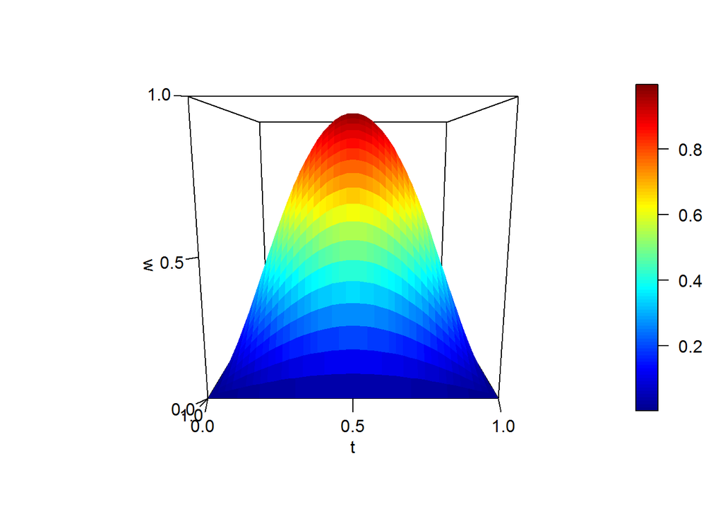

```r
persp3D(sol$x, sol$y, sol$w[, , 1],
        xlab="x", ylab="t", zlab="w",
        ticktype="detailed", nticks=4, phi=10, theta=90)
```

Next we plot the solution at the final time $t=0.2$.

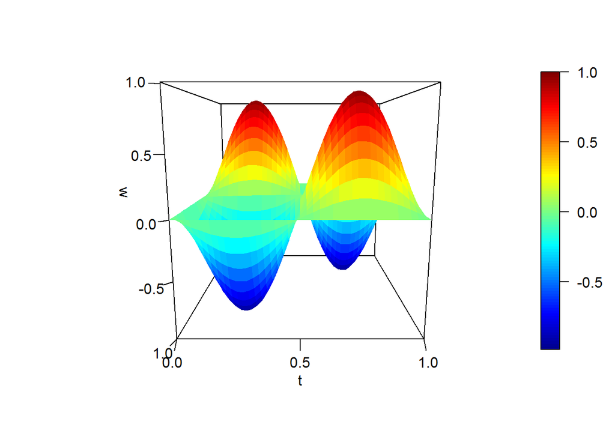

```r
persp3D(sol$x, sol$y, sol$w[, , 21],
        xlab="x", ylab="t", zlab="w",
        ticktype="detailed", nticks=4, phi=10, theta=90)
```

To follow the time evolution of the solution we make a little movie.

```r
for (n in 1:21) {
    persp3D(sol$x, sol$y, sol$w[, , n],
        xlab="x", ylab="t", zlab="w", zlim=c(-1, 1.3), clim=c(-1, 1.3),
        ticktype="detailed", nticks=4, phi=12, theta=90)
}
```

[video not shown]

To check our method we compare it to the exact solution which is
$$u(x,y,t) = e^{-2\pi^2 t}\sin(\pi x)\sin(\pi y)
+\left(1-e^{-8\pi^2 t}\right)\sin(2\pi x)\sin(2\pi y)$$
We calculate the maximum absolute error in the numerical solution at $t=0.2$

```r
t <- 0.2
u <- outer(sol$x, sol$y,
           function(x, y, t) exp(-2*pi^2*t)*sin(pi*x)*sin(pi*y) +
               (1-exp(-8*pi^2*t))*sin(2*pi*x)*sin(2*pi*y), t)
max(abs(u-sol$w[, , 21]))
```

```
[1] 0.002070063
```

This is small, as expected. We can also see that if we halve the step size in all directions we get an error that is about one quarter as large, as expected from a method that is of $O(\tau^2+h_1^2+h_2^2)$.

```r
sol2 <- ADI(u0=function(x, y) sin(pi*x)*sin(pi*y), K=1,
           f=function(x, y, t) 8*pi^2*sin(2*pi*x)*sin(2*pi*y),
           L1=1, L2=1, N1=80, N2=80, T=0.2, M=40)
u2 <- outer(sol2$x, sol2$y,
           function(x, y, t) exp(-2*pi^2*t)*sin(pi*x)*sin(pi*y) +
               (1-exp(-8*pi^2*t))*sin(2*pi*x)*sin(2*pi*y), t)
max(abs(u2-sol2$w[, , 41]))
```

```
[1] 0.0005170408
```

## Exercise

Solve the same equation but with boundary conditions
$$u(0,y,t) = t\sin(2\pi y), ~~ u(L_1,y,t) = ty(1-y), ~~ u(x,0,t) = u(x,L_2,t) = 0$$
This will require changes to the function `ADI()`.